# Use Case 05: Analysis of trials (including methods for analysing spillover)

The `CRTanalysis()` function is a wrapper for different statistical analysis packages that can be used to analyse either simulated or real trial datasets. It is designed for use in simulation studies of different analytical methods for spatial CRTs by automating the data processing and selecting some appropriate analysis options. It does not replace conventional use of these packages. Real field trials very often entail complications that are not catered for any of the analysis options in `CRTanalysis()` and it does not aspire to carry out the full analytical workflow for a trial. It can be used as part of a wider workflow. In particular the usual object output by the statistical analysis package constitutes the `model_object` element within the `CRTanalysis` object generated by `CRTanalysis()`. This can be accessed by the usual methods (e.g `predict()`, `summary()`, `plot()`) which may be needed for diagnosing errors, assessing goodness of fit, and for identifying needs for additional analyses.

## Statistical Methods

All these analysis methods can be used to carry out a simple comparision of outcomes between trial arms. Each offers different additional functionality, and has its own limitations (see Table 5.1). Some of these limitations are specific to the options offered within `CRTanalysis()`, which does not embrace the full range of options of the packages that are ‘wrapped’. These are specified using the `method` argument of the function.

Table 5.1. Available statistical methods

[output not shown]

For the analysis of proportions, the outcome in the control arm is estimated as: $\hat{p}_{C} = \frac{1}{1 + exp(-\beta_1)}$, in the intervention arm as $\hat{p}_{I} = \frac{1}{1 + exp(-\beta_1-\beta_2)}$, and the efficacy is estimated as $\tilde{E}_{s} = 1- \frac{\tilde{p}_{I}}{\tilde{p}_{C}}$ where $\beta_1$ is the intercept term and $\beta_2$ the incremental effect associated with the intervention.

`summary("<analysis>"")` is used to view the key results of the trial. To display the output from the statistical procedure that is called, try `<analysis>$model_object` or `summary("<analysis>$model_object")`.

```r
library(CRTspat)
example <- readdata("exampleCRT.txt")
analysisT <- CRTanalysis(example, method = "T")
summary(analysisT)
```

```
##
## =====================CLUSTER RANDOMISED TRIAL ANALYSIS =================
## Analysis method:  T
## Link function:  logit
## Model formula:  arm + (1 | cluster)
## No modelling of spillover
## Estimates:       Control: 0.364 (95% CL: 0.286 0.451)
##             Intervention: 0.21 (95% CL: 0.147 0.292)
##                 Efficacy: 0.423 (95% CL: 0.208 0.727)
## Coefficient of variation: 48.425 (95% CL: 35.969 75.865)
##
## P-value (2-sided):  0.006879064
```

```r
analysisT$model_object
```

```
##
##  Two Sample t-test
##
## data:  lp by arm
## t = 2.9818, df = 22, p-value = 0.006879
## alternative hypothesis: true difference in means between group control and group intervention is not equal to 0
## 95 percent confidence interval:
##  0.2332638 1.2989425
## sample estimates:
##      mean in group control mean in group intervention
##                 -0.5561662                 -1.3222694
```

## Assessing model fit

The `method = "LME4"` option outputs the deviance of the model and the Akaike information criterion (AIC), which can be used to select the best fitting model. The deviance information criterion (DIC) and Bayesian information criterion (BIC) perform the same role for `method = "INLA"`. For `method = "MCMC"` goodness-of-fit is assessed using the LOO criterion (package loo). The comparison of results with `cfunc = "X"` and `cfunc = "Z"` is used to assess whether the intervention effect is likely to be due to chance. With `method = "T"`, `cfunc = "X"` provides a significance test of the intervention effect directly. The models with spillover (see below) can be compared by that with `cfunc = "X"` to evaluate whether spillover has led to an important bias.

## Spillover

`CRTanalysis()` provides options for analysing spillover effects either as function of a Euclidean distance or as a function of a surround measure:

#### Models that do not consider spillover

Models that do not consider spillover can be fitted using options `Z` and `X`. These are included both to allow conventional analyses (see above), and also to enable model selection using and likelihood ratio tests, the Akaike information criterion (AIC), deviance information criterion (DIC) or Bayesian information criterion (BIC) .

#### Spillover as a function of distance

These methods require a measure of distance from the boundary between the trial arms, with locations in the control arm assigned negative values, and those in the intervention arm assigned positive values. The functional forms for this relationship is specified by the value of `cfunc` (Table 5.2).

Table 5.2. Available spillover functions

| `cfunc` | Description | Formula for $P\left( d \right)$ | Compatible `method`(s) |
| --- | --- | --- | --- |
| `Z` | No intervention effect | $P\left( d \right) = \ 0\$ | `GEE` `LME4` `INLA` `MCMC` |
| `X` | Simple intervention effect | $\begin{matrix} P\left( d \right) = \ 0\ for\ d\ < \ 0 \\ P\left( d \right) = \ 1\ for\ d\ > \ 0 \\ \end{matrix}\$ | `T` `GEE` `LME4` `INLA` `MCMC` |
| `L` | inverse logistic (sigmoid) | $P\left( d \right) = \ \frac{1}{\left( 1\ + \ exp\left( - d/S \right) \right)}$ | `LME4` `INLA` `MCMC` |
| `P` | inverse probit (error function) | $P\left( d \right) = 1\ +\ erf\left(\frac{d}{S\sqrt2}\right)$ | `LME4` `INLA` `MCMC` |
| `S` | piecewise linear | $\begin{matrix} P\left( d \right) = \ 0\ for\ d\ < \ - S/2\ \ \ \ \ \ \ \ \ \ \ \ \ \ \ \ \ \ \ \ \ \ \ \ \\ P\left( d \right) = \ \left(S/2\ + \ d \right)/S\ for\ - S/2 < d\ < \ S/2\\ P\left( d \righ… | `LME4` `INLA` `MCMC` |
| `R` | rescaled linear | $P\left( d \right) =\frac{d\ -\ min(d)}{max(d)\ -\ min(d)}$ | `LME4` `INLA` `MCMC` |
| `D` | diffusion | $P\left( d \right) = 1\ +\ erf\left(\frac{d}{S\sqrt2}\right)$ | `MCMC` |

With `cfunc` options other than `D` the spillover function is applied on the scale of the linear predictor. With option `D` the spillover function is on the same scale as the outcome (which matches the linear predictor only if `link = "identity"`). Option `D` corresponds to the [diffusion model of spillover](https://doi.org/10.21203/rs.3.rs-5423058/v1).

`cfunc` options `P`, `L`, `S` and `D` lead to non-linear models in which the spillover scale parameter (`S`) must be estimated. With the `LME4` and `INLA` options this is done by optimising the `scale_par` by running the generalised linear model iteratively within a one-dimensional optimisation of the goodness of fit of the model in `stats::optimize()`. With the `MCMC` option the MCMC algorithm fits the scale parameter as part of the overall non-linear model fit.

Different values for `cfunc` lead to the fitted curves shown in Figure 5.1. The light blue shaded part of the plot corresponds to the spillover interval in those cases where this is estimated.

```r
analysisLME4_Z <- CRTanalysis(example, method = "LME4", cfunc = "Z")
summary(analysisLME4_Z)
```

```
##
## =====================CLUSTER RANDOMISED TRIAL ANALYSIS =================
## Analysis method:  LME4
## Link function:  logit
## Model formula:  (1 | cluster)
## No comparison of arms
## Estimates:       Control: 0.285 (95% CL: 0.231 0.346)
## Coefficient of variation: 48.425 (95% CL: 35.969 75.865)
## deviance                :  NA
## AIC                     :  1391.609
```

```r
analysisLME4_X <- CRTanalysis(example, method = "LME4", cfunc = "X")
summary(analysisLME4_X)
```

```
##
## =====================CLUSTER RANDOMISED TRIAL ANALYSIS =================
## Analysis method:  LME4
## Link function:  logit
## Model formula:  arm + (1 | cluster)
## No modelling of spillover
## Estimates:       Control: 0.367 (95% CL: 0.291 0.448)
##             Intervention: 0.216 (95% CL: 0.16 0.281)
##                 Efficacy: 0.412 (95% CL: 0.171 0.587)
## Coefficient of variation: 48.425 (95% CL: 35.969 75.865)
## deviance                :  NA
## AIC                     :  1385.898
```

```r
analysisLME4_P <- CRTanalysis(example, method = "LME4", cfunc = "P")
summary(analysisLME4_P)
```

```
##
## =====================CLUSTER RANDOMISED TRIAL ANALYSIS =================
## Analysis method:  LME4
## Link function:  logit
## Measure of distance or surround: Signed distance to other arm (km)
##  with estimation of scale parameter.
## Model formula:  effect + (1 | cluster)
## Error function model for spillover
## Estimates:       Control: 0.418 (95% CL: 0.331 0.512)
##             Intervention: 0.186 (95% CL: 0.135 0.249)
##                 Efficacy: 0.554 (95% CL: 0.331 0.705)
##          Scale parameter: 0.45 (95% CL: 0.45 0.45)
##   Spillover interval(km): 1.749 (95% CL: 1.728 1.762)
## Pr in spillover interval: 0.685 (95% CL: 0.685 0.685)
##    Ipsilateral Spillover: 0.009 (95% CL: 0 0.094)
##  Contralateral Spillover: 0.032 (95% CL: 0 0.13)
## Coefficient of variation: 48.425 (95% CL: 35.969 75.865)
## deviance                :  NA
## AIC                     :  1382.215 including penalty for the spillover scale parameter
```

```r
analysisLME4_L <- CRTanalysis(example, method = "LME4", cfunc = "L")
summary(analysisLME4_L)
```

```
##
## =====================CLUSTER RANDOMISED TRIAL ANALYSIS =================
## Analysis method:  LME4
## Link function:  logit
## Measure of distance or surround: Signed distance to other arm (km)
##  with estimation of scale parameter.
## Model formula:  effect + (1 | cluster)
## Sigmoid (logistic) function for spillover
## Estimates:       Control: 0.415 (95% CL: 0.331 0.507)
##             Intervention: 0.186 (95% CL: 0.135 0.251)
##                 Efficacy: 0.551 (95% CL: 0.329 0.701)
##          Scale parameter: 0.249 (95% CL: 0.249 0.249)
##   Spillover interval(km): 1.81 (95% CL: 1.776 1.823)
## Pr in spillover interval: 0.706 (95% CL: 0.706 0.706)
##    Ipsilateral Spillover: 0.009 (95% CL: 0 0.098)
##  Contralateral Spillover: 0.03 (95% CL: 0 0.127)
## Coefficient of variation: 48.425 (95% CL: 35.969 75.865)
## deviance                :  NA
## AIC                     :  1382.201 including penalty for the spillover scale parameter
```

```r
analysisLME4_S <- CRTanalysis(example, method = "LME4", cfunc = "S")
summary(analysisLME4_S)
```

```
##
## =====================CLUSTER RANDOMISED TRIAL ANALYSIS =================
## Analysis method:  LME4
## Link function:  logit
## Measure of distance or surround: Signed distance to other arm (km)
##  with estimation of scale parameter.
## Model formula:  effect + (1 | cluster)
## Piecewise linear function for spillover
## Estimates:       Control: 0.423 (95% CL: 0.335 0.516)
##             Intervention: 0.185 (95% CL: 0.134 0.247)
##                 Efficacy: 0.563 (95% CL: 0.34 0.71)
##          Scale parameter: 1.674 (95% CL: 1.674 1.674)
##   Spillover interval(km): 1.586 (95% CL: 1.586 1.593)
## Pr in spillover interval: 0.633 (95% CL: 0.633 0.633)
##    Ipsilateral Spillover: 0.012 (95% CL: 0 0.11)
##  Contralateral Spillover: 0.051 (95% CL: 0 0.139)
## Coefficient of variation: 48.425 (95% CL: 35.969 75.865)
## deviance                :  NA
## AIC                     :  1382.094 including penalty for the spillover scale parameter
```

```r
analysisLME4_R <- CRTanalysis(example, method = "LME4", cfunc = "R")
summary(analysisLME4_R)
```

```
##
## =====================CLUSTER RANDOMISED TRIAL ANALYSIS =================
## Analysis method:  LME4
## Link function:  logit
## Measure of distance or surround: Signed distance to other arm (km)
##  with no non-linear parameter.
## Model formula:  effect + (1 | cluster)
## Rescaled linear function for spillover
## Estimates:       Control: 0.585 (95% CL: 0.386 0.76)
##             Intervention: 0.116 (95% CL: 0.06 0.211)
##                 Efficacy: 0.8 (95% CL: 0.478 0.918)
##          Scale parameter: 1 (95% CL: 1 1)
##   Spillover interval(km): 6.372 (95% CL: 6.243 6.433)
## Pr in spillover interval: 0.997 (95% CL: 0.997 0.997)
## Coefficient of variation: 48.425 (95% CL: 35.969 75.865)
## deviance                :  NA
## AIC                     :  1384.711
```

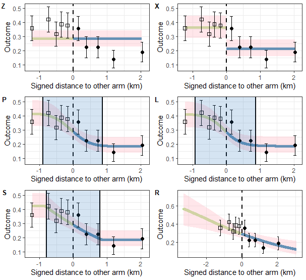

```r
p0 <- plotCRT(analysisLME4_Z, map = FALSE)
p1 <- plotCRT(analysisLME4_X, map = FALSE)
p2 <- plotCRT(analysisLME4_P, map = FALSE)
p3 <- plotCRT(analysisLME4_L, map = FALSE)
p4 <- plotCRT(analysisLME4_S, map = FALSE)
p5 <- plotCRT(analysisLME4_R, map = FALSE)
library(cowplot)
plot_grid(p0, p1, p2, p3, p4, p5, labels = c('Z', 'X', 'P', 'L', 'S', 'R'), label_size = 10, ncol = 2)
```

*Fig 5.1 Fitted curves for the example dataset with different options for `cfunc`*

The piecewise linear spillover function, `cfunc = "S"`, is only linear on the scale of the linear predictor. When used in a logistic model, as here, the transformation via the inverse of the link function leads to a slightly curved plot (Figure 5.1S). The rescaled linear function, `cfunc = "R"`, is provided as a comparator and for use with `distance` values other than `distance = "nearestDiscord"` see below (it should not be used to estimate the spillover interval).

#### Spillover as a function of surround

Spillover can also be analysed by assuming the effect size to be a function of the number of intervened locations in the surroundings of the location [Anaya-Izquierdo & Alexander(2021)](https://onlinelibrary.wiley.com/doi/full/10.1111/biom.13316). Several different surround functions are available. These are specified by the `distance` parameter (Table 5.3).

Table 5.3. Available surround functions

| `distance` | Description | Details |
| --- | --- | --- |
| `nearestDiscord` | Distance to nearest discordant location | The default. This is used for analyses by distance (see above) |
| `hdep` | Tukey half-depth | Algorithm of [Rousseeuw & Ruts(1996)](https://www.jstor.org/stable/2986073) |
| `sdep` | Simplicial depth | Algorithm of [Rousseeuw & Ruts(1996)](https://www.jstor.org/stable/2986073) |
| `disc` | disc | The number of intervened locations within the specified radius (excluding the location itself) as described by [Anaya-Izquierdo & Alexander(2021)](https://onlinelibrary.wiley.com/doi/full/10.1111/biom… |
| `kern` | Sum of kernels | The sum of normal kernels |

The `compute_distance()` function is provided to compute these quantities, so that they can be described, compared, and analysed independently of `CRTanalysis()`. Note that the values of the surround calculated by `compute_distance()` are scaled to avoid correlation with the spatial density of the points (see documentation) and so are not equivalent to the quantities reported in the original publications.

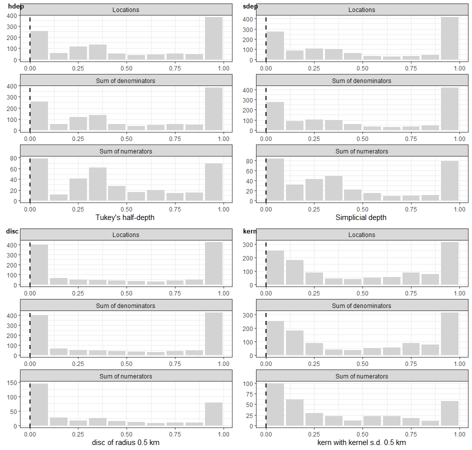

```r
examples <- compute_distance(example, distance = "hdep")
ps1 <- plotCRT(examples, distance = "hdep", legend.position = c(0.6, 0.8))
ps2 <- plotCRT(examples, distance = "sdep")
examples <- compute_distance(examples, distance = "disc", scale_par = 0.5)
ps3 <- plotCRT(examples, distance = "disc")
examples <- compute_distance(examples, distance = "kern", scale_par = 0.5)
ps4 <- plotCRT(examples, distance = "kern")
plot_grid(ps1, ps2, ps3, ps4, labels = c('hdep', 'sdep', 'disc', 'kern'), label_size = 10, ncol = 2)
```

*Fig 5.2 Stacked bar plots for different surrounds*

If `distance` is assigned a value of either `hdep`, `sdep`, then `cfunc = "R"` is used by default and the overall effect size is computed by comparing the fitted values of the model for a surround value of zero with that of the maximum of the surround in the data. If `distance = "disc"` or `distance = "kern"` and `scale_par` is assigned a value, then `cfunc = "R"` is also used. If `cfunc = "E"` is specified then an escape function is fitted with the scale parameter estimated in the same way as in the scale parameter in other models (see above Table 5.2).

```r
examples_hdep <- CRTanalysis(examples, method = "LME4", distance = "hdep", cfunc = 'R')
summary(examples_hdep)
```

```
##
## =====================CLUSTER RANDOMISED TRIAL ANALYSIS =================
## Analysis method:  LME4
## Link function:  logit
## Measure of distance or surround: Tukey half-depth
##  with no non-linear parameter.
## Model formula:  effect + (1 | cluster)
## Rescaled linear function for spillover
## Estimates:       Control: 0.382 (95% CL: 0.293 0.478)
##             Intervention: 0.208 (95% CL: 0.151 0.282)
##                 Efficacy: 0.454 (95% CL: 0.168 0.644)
##          Scale parameter: 1 (95% CL: 1 1)
##   Spillover interval(km): 0.939 (95% CL: 0.928 0.947)
## Pr in spillover interval: 0.529 (95% CL: 0.529 0.529)
## Coefficient of variation: 48.425 (95% CL: 35.969 75.865)
## deviance                :  NA
## AIC                     :  1385.89
```

```r
ps4 <- plotCRT(examples_hdep)
examples_sdep <- CRTanalysis(examples, method = "LME4", distance = "sdep", cfunc = 'R')
summary(examples_sdep)
```

```
##
## =====================CLUSTER RANDOMISED TRIAL ANALYSIS =================
## Analysis method:  LME4
## Link function:  logit
## Measure of distance or surround: Simplicial depth
##  with no non-linear parameter.
## Model formula:  effect + (1 | cluster)
## Rescaled linear function for spillover
## Estimates:       Control: 0.394 (95% CL: 0.309 0.488)
##             Intervention: 0.199 (95% CL: 0.144 0.267)
##                 Efficacy: 0.495 (95% CL: 0.25 0.661)
##          Scale parameter: 1 (95% CL: 1 1)
##   Spillover interval(km): 0.937 (95% CL: 0.927 0.945)
## Pr in spillover interval: 0.485 (95% CL: 0.485 0.485)
## Coefficient of variation: 48.425 (95% CL: 35.969 75.865)
## deviance                :  NA
## AIC                     :  1382.417
```

```r
ps5 <- plotCRT(examples_sdep)
examples_disc <- CRTanalysis(examples, method = "LME4", distance = "disc", cfunc = 'R', scale_par = 0.15)
summary(examples_disc)
```

```
##
## =====================CLUSTER RANDOMISED TRIAL ANALYSIS =================
## Analysis method:  LME4
## Link function:  logit
## Measure of distance or surround: disc of radius 0.15 km
##  with precalculated scale parameter of 0.15:
## Model formula:  effect + (1 | cluster)
## Rescaled linear function for spillover
## Estimates:       Control: 0.387 (95% CL: 0.312 0.47)
##             Intervention: 0.2 (95% CL: 0.15 0.262)
##                 Efficacy: 0.482 (95% CL: 0.276 0.632)
##          Scale parameter: 0.15 (95% CL: 0.15 0.15)
##   Spillover interval(km): 0.938 (95% CL: 0.928 0.945)
## Pr in spillover interval: 0.089 (95% CL: 0.089 0.089)
## Coefficient of variation: 48.425 (95% CL: 35.969 75.865)
## deviance                :  NA
## AIC                     :  1380.274
```

```r
ps6 <- plotCRT(examples_disc,legend.position = c(0.8, 0.8))
examples_kern <- CRTanalysis(examples, method = "LME4", distance = "kern", cfunc = 'R', scale_par = 0.15)
summary(examples_kern)
```

```
##
## =====================CLUSTER RANDOMISED TRIAL ANALYSIS =================
## Analysis method:  LME4
## Link function:  logit
## Measure of distance or surround: kern with kernel s.d. 0.15 km
##  with precalculated scale parameter of 0.15:
## Model formula:  effect + (1 | cluster)
## Rescaled linear function for spillover
## Estimates:       Control: 0.406 (95% CL: 0.328 0.491)
##             Intervention: 0.185 (95% CL: 0.137 0.247)
##                 Efficacy: 0.544 (95% CL: 0.342 0.684)
##          Scale parameter: 0.15 (95% CL: 0.15 0.15)
##   Spillover interval(km): 0.935 (95% CL: 0.925 0.944)
## Pr in spillover interval: 0.59 (95% CL: 0.59 0.59)
## Coefficient of variation: 48.425 (95% CL: 35.969 75.865)
## deviance                :  NA
## AIC                     :  1375.677
```

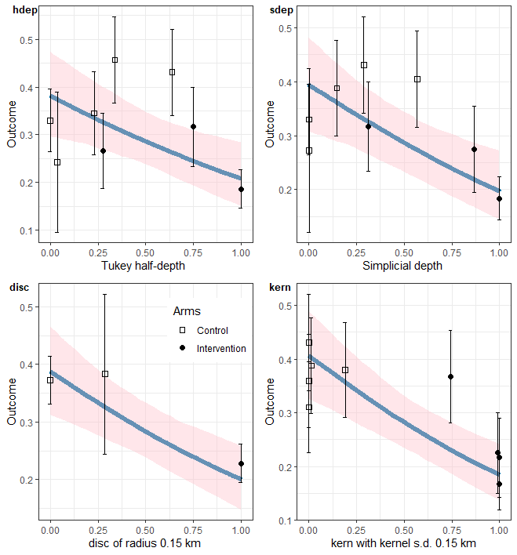

```r
ps7 <- plotCRT(examples_kern)
plot_grid(ps4, ps5, ps6, ps7, labels = c('hdep', 'sdep', 'disc', 'kern'), label_size = 10, ncol = 2)
```

*Fig 5.3 Fitted curves for the example dataset with different surrounds*

## Geostatistical models and mapping results

To carry out a geostatistical analysis with `method = "INLA"` a prediction mesh is needed. By default a very low resolution mesh is created (creating a high resolution mesh is computationally expensive). To create a 100m INLA mesh for `<MyTrial>`, use:

`mesh <- compute_mesh(trial = <MyTrial> , pixel = 0.1)`